# Projekt_Szeregi_Czasowe

Olszewski Konrad

2023-06-12

```r
setwd('C:/Users/r_ol/Desktop/Projekt_szregi_czasowe')
getwd()
```

```
## [1] "C:/Users/r_ol/Desktop/Projekt_szregi_czasowe"
```

```r
library(forecast)
library(readxl)
library(tseries)
library(fma)
```

## **Import danych**

#### **Szereg z sezonowością i trendem**

```r
data <- read.csv("SEAS00SKM086NEST.csv", sep=",")
data <- data.frame(data, row.names = T)
szereg1 <- ts(data, start = c(1996,1),end = c(2023,4),frequency = 12)
sz1 <- window(szereg1, start=c(2003 ,1))
```

#### **Szereg z trendem**

```r
data2 <- read.csv("INDLORSGPTDSTSAM.csv", sep=",")
pp2 <- data.frame(data2, row.names = T)
trend_szereg <- ts(pp2, start = c(1996,5),end = c(2022,11),frequency = 12)
trend_szereg <- window(trend_szereg, start=c(2005,1), end = c(2022,11))
```

# **1. Wstęp - opis użytych danych**

#### Do wykonania projektu zostały wybrane dwa szeregi czasowe przedstawiające “Produkt Krajowy Brutto (PKB): Trend dla Indii” a także “Zharmonizowany indeks cen konsumpcyjnych: Żywność sezonowa dla Słowacji”. Pierwszy z nich wykazuje wyraźny trend rosnącego PKDB dla Indii natomiast drugi ukazuje sezonowość jak i trend. W dalszych krokach zostały one podanie analizie według opisanych wytycznych.

# **2. Omówienie głównych cech analizowanych szeregów na podstawie różnych typów wykresów**

## **2.1 Wykres miesięczny monthplot()**

#### **Szereg czasowy z sezonowością i trendem**

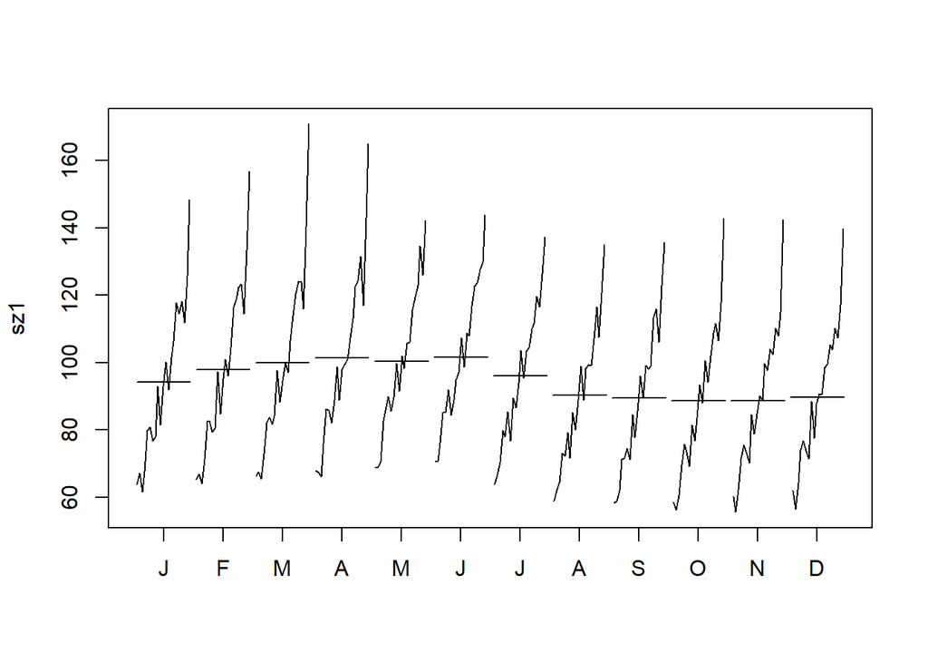

```r
monthplot(sz1)
```

#### **Szereg czasowy z trendem**

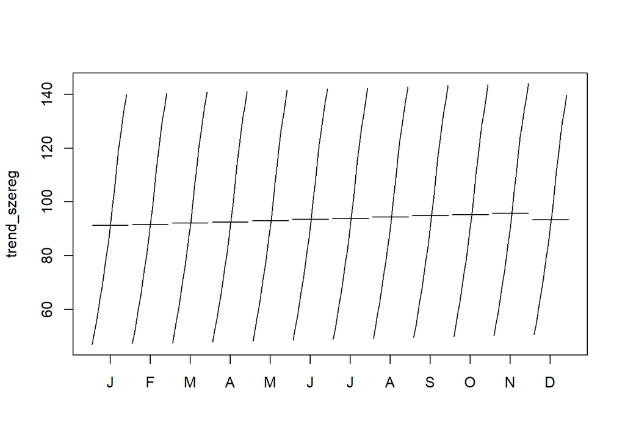

```r
monthplot(trend_szereg)
```

#### Powyższe wykresy ukazują miesięczny przebieg wartości badanych szeregów. Jak można zauważyć oba posiadaja trend wzrostowy naromiast szereg zawierający również sezonowość dla danych miesięcy w określonych latach pokazuje pewne wartości tej sezonowości.

## **2.2 Wykres pudełkowy boxplot()**

#### **Szereg czasowy z sezonowością i trendem**

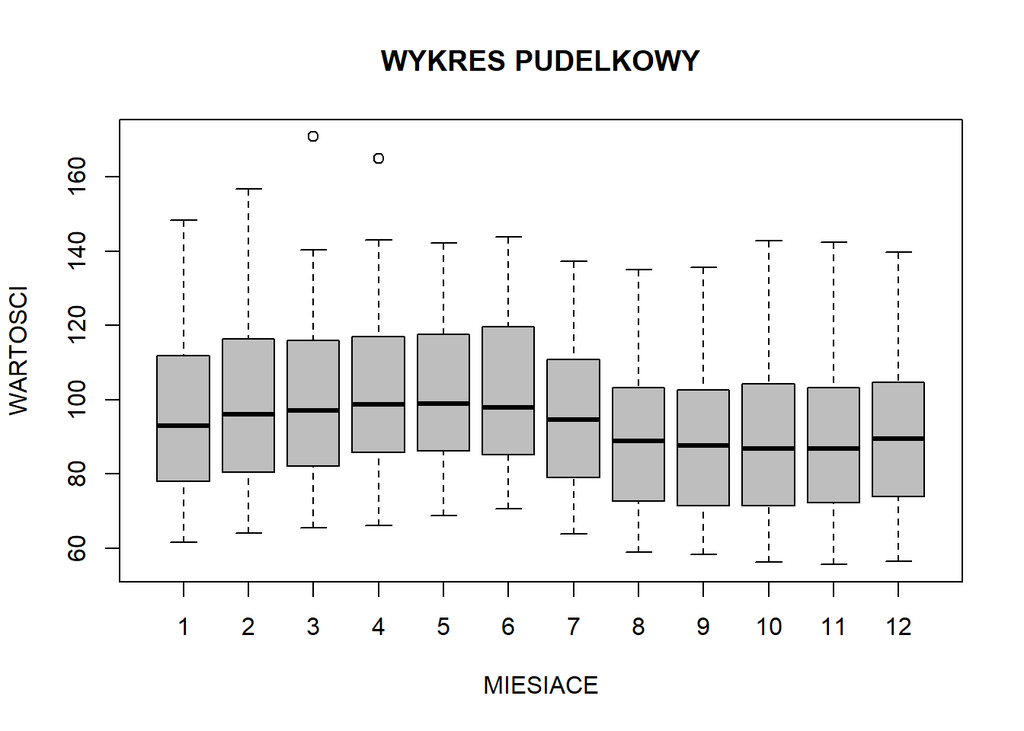

```r
boxplot(sz1 ~ cycle(sz1),
        xlab = "MIESIACE",
        ylab = "WARTOSCI",
        main = "WYKRES PUDELKOWY",
        col = "grey")
```

#### **Szereg czasowy z trendem**

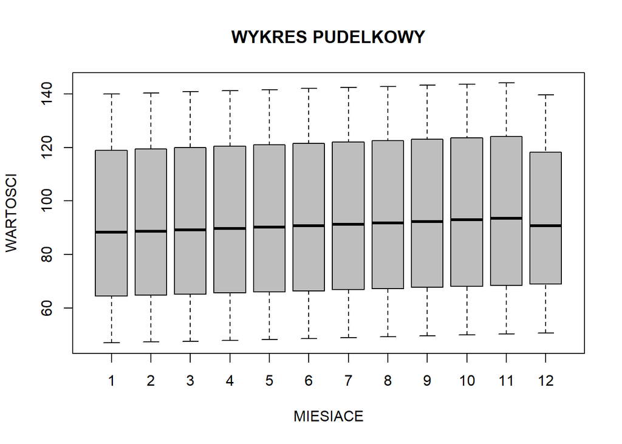

```r
boxplot(trend_szereg ~ cycle(trend_szereg),
        xlab = "MIESIACE",
        ylab = "WARTOSCI",
        main = "WYKRES PUDELKOWY",
        col = "grey")
```

#### Dzięki powyższym wykresom pudełkowym możemy odczytać medianę, kwartyle czy wartości odstające oraz wąsy, które przedstawiają wartości oddalone odpowiednio od danych kwartyli. Jak można zauważyc mediana dla szeregu z trendem jest dość na stałym poziomie w zakresie wszystkich obserwowanych miesięcy w przeciwieństwie do drugiego szregu, który w danych miesiącach zniża swoje wartości.

## **2.3 Wykres sezonowy seasonalplot()**

#### **Szereg czasowy z sezonowością i trendem**

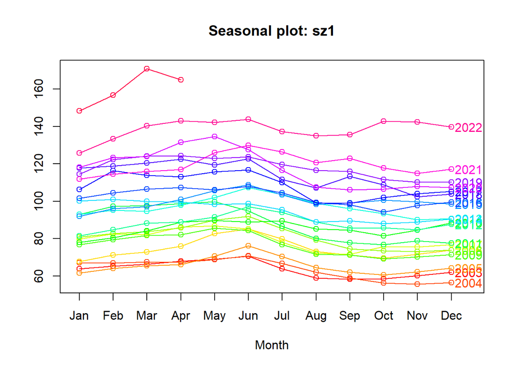

```r
seasonplot(sz1,col = rainbow(21),
           year.labels = TRUE)
```

#### **Szereg czasowy z trendem**

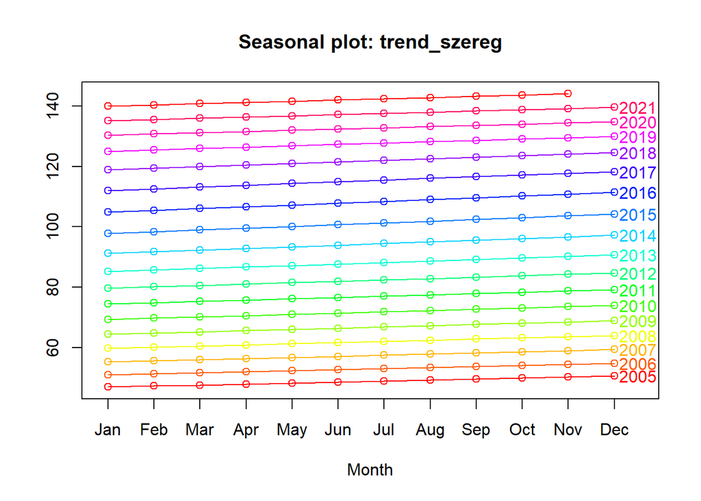

```r
seasonplot(trend_szereg,col = rainbow(17),
           year.labels = TRUE)
```

#### Analizując powyższe wykresy można zauważyć regularny wzrost wartości dla szeregu **sz1** od stycznia do czerwca odpowiednich lat oraz jego spadek po tym okresie. Natomiast obserwując szereg **trend_szereg** widoczny jest trend wzrostowy w kolejnych latach oraz miesiącach.

## **2.4 Wykresy lag.plot(), acf(), pacf()**

#### **Szereg czasowy z sezonowością i trendem**

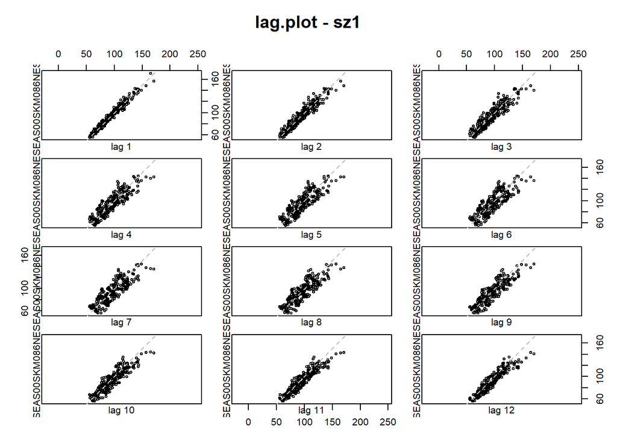

```r
lag.plot(sz1, lags=12, do.lines = FALSE, main = "lag.plot - sz1")
```

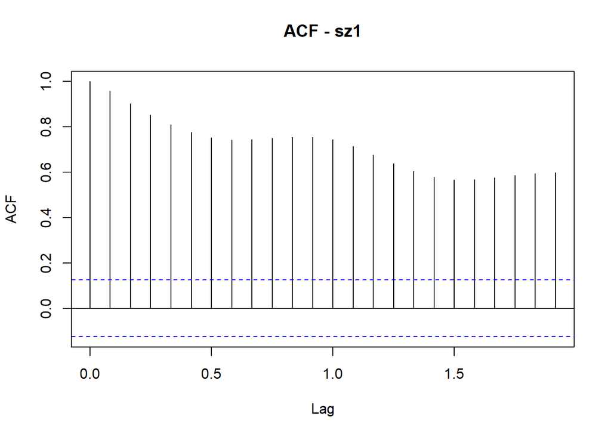

```r
acf(sz1, main = "ACF - sz1")
```

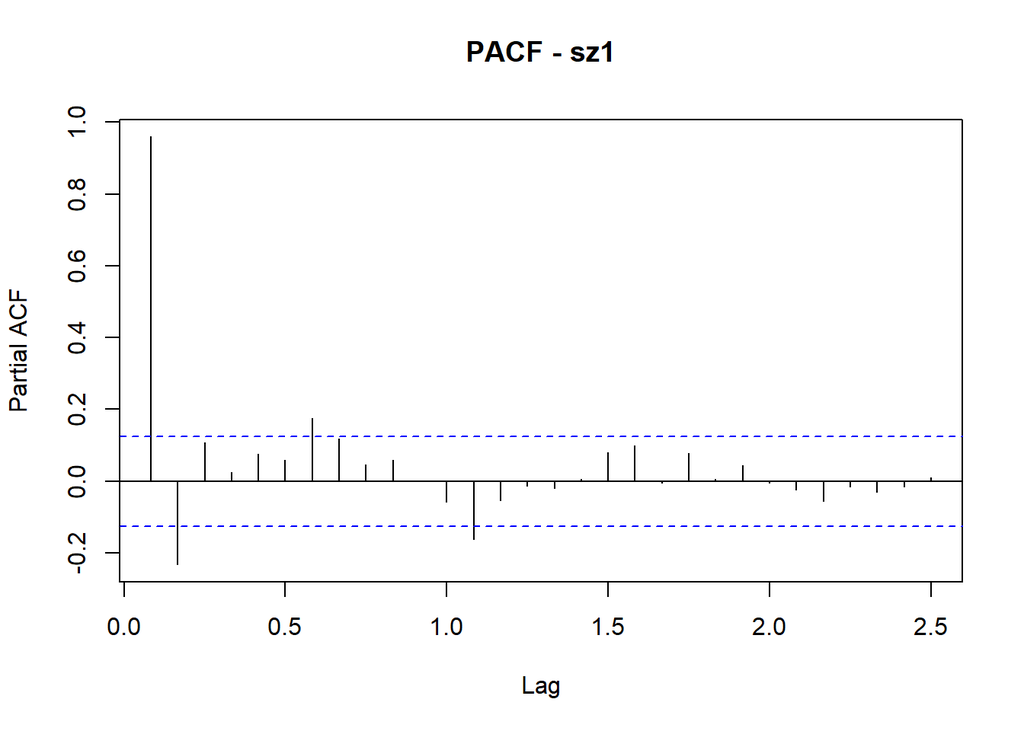

```r
pacf(sz1, main = "PACF - sz1", lag.max = 30)
```

#### **Szereg czasowy z trendem**

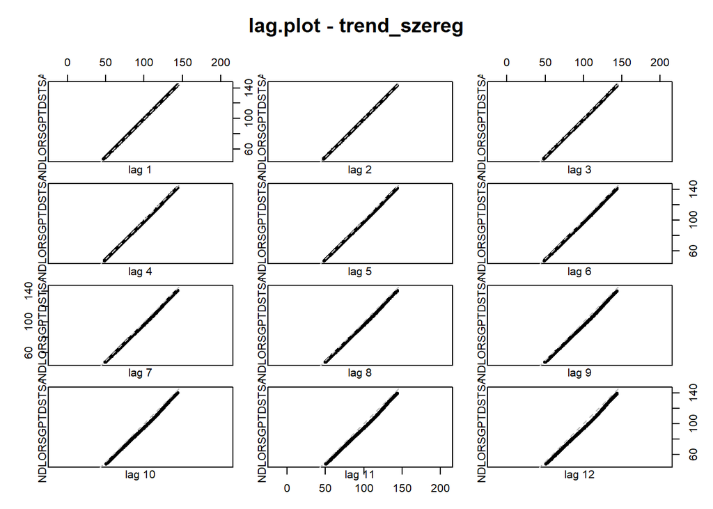

```r
lag.plot(trend_szereg, lags=12, do.lines = FALSE, main = "lag.plot - trend_szereg")
```

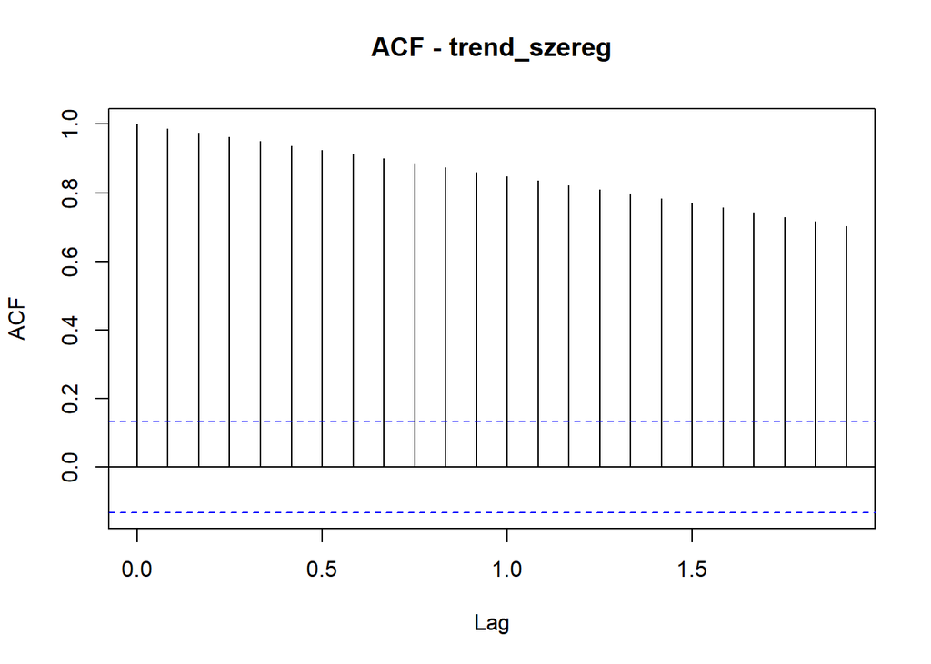

```r
acf(trend_szereg, main = "ACF - trend_szereg")
```

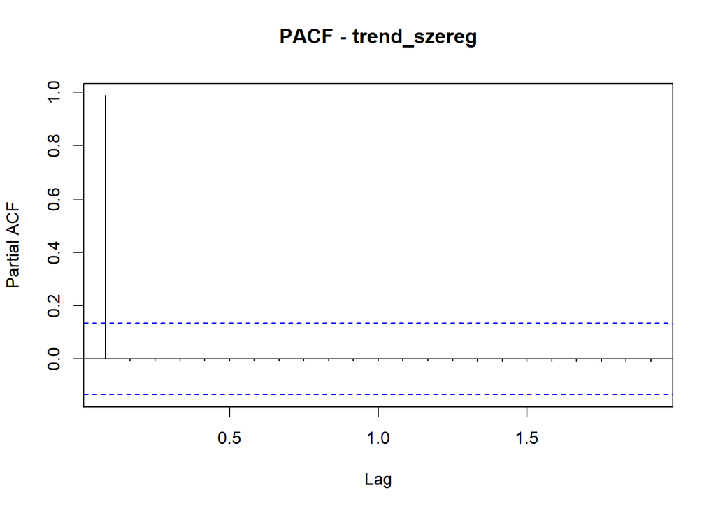

```r
pacf(trend_szereg, main = "PACF - trend_szereg")
```

#### Analizując kolejny szereg możemy przy analizie wykresu opóźnień wysoką korelację na każdym w tym najbardziej na 1 co wskazuje na trend. Przechodząc do wykresu ACF możemy zobaczyć regularnie opadające wartości co wskazuje również na występowanie trendu natomiast patrząc na wykres PACF można zauważyć jedną daleko odsuniętą wartość od przedziału ufności.

# **3. Dekompozycja**

## **3.1 Dekompozycja multiplikatywna i addytywna**

#### **Szereg czasowy z sezonowością i trendem**

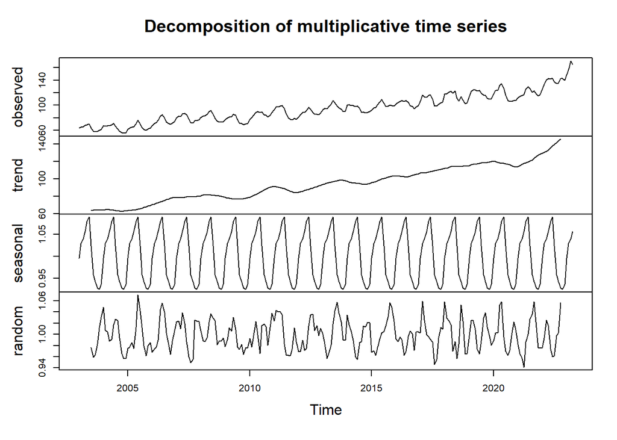

```r
multip <- decompose(sz1, type = "multiplicative")
plot(multip)
```

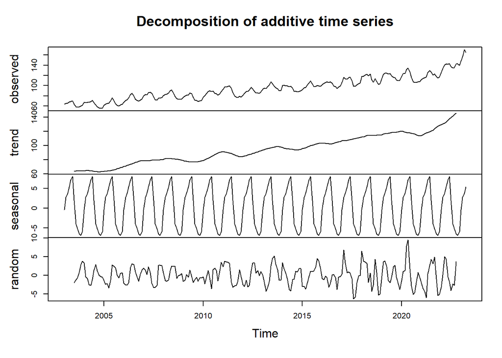

```r
additive <- decompose(sz1, type = "additive")
plot(additive)
```

#### **Szereg czasowy z trendem**

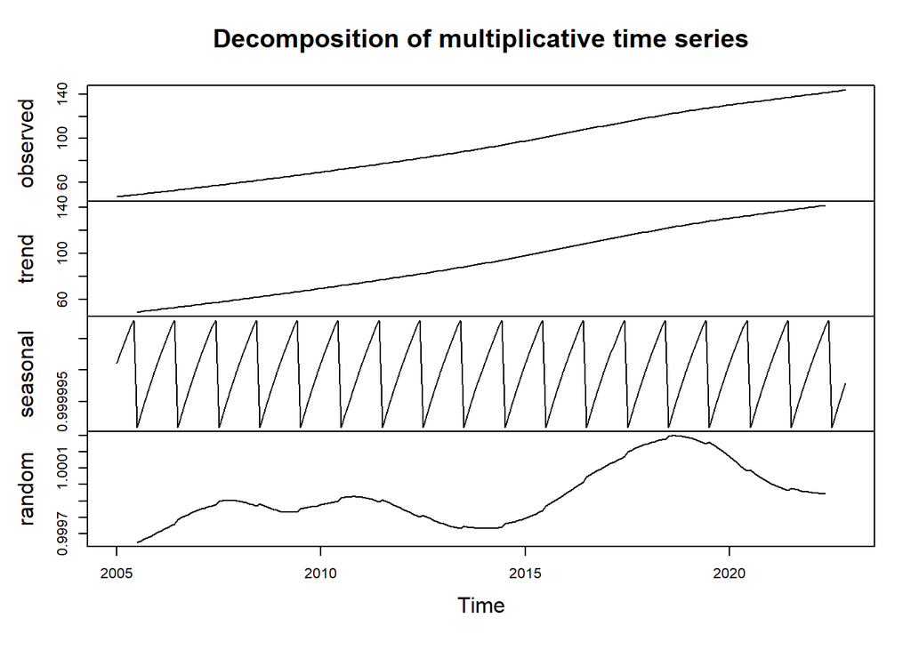

```r
multip_trend <- decompose(trend_szereg, type = "multiplicative")
plot(multip_trend)
```

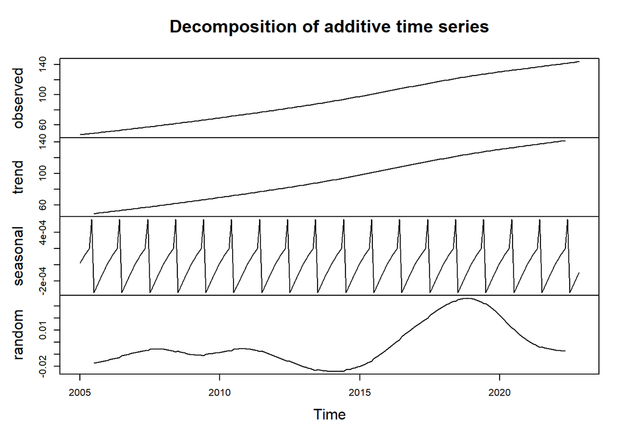

```r
additive_trend <- decompose(trend_szereg, type = "additive")
plot(additive_trend)
```

#### W porównaniu dwóch różnych kompozycji jednyne różnice można zauważyć w wartościach dla wiersza **random** oraz **seasonal**.

## **3.2 Dekompozycja za pomocą ruchomej średniej**

#### **Szereg czasowy z sezonowością i trendem**

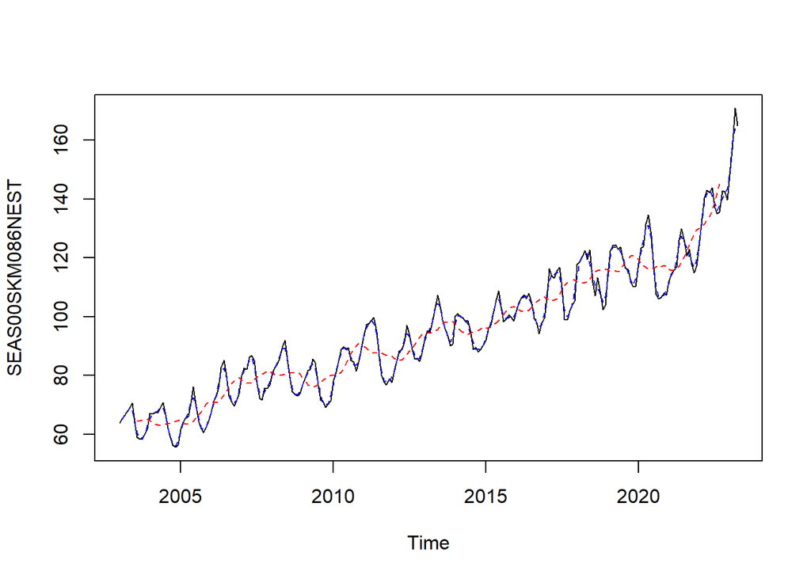

```r
f <- filter(sz1, sides = 2, filter = rep(1/3,3))
f2 <- filter(sz1, sides = 2, filter = rep(1/15,15))
plot(sz1)
lines(f, col = "blue", lty=2)
lines(f2, col = "red", lty=2)
```

#### **Szereg czasowy z trendem**

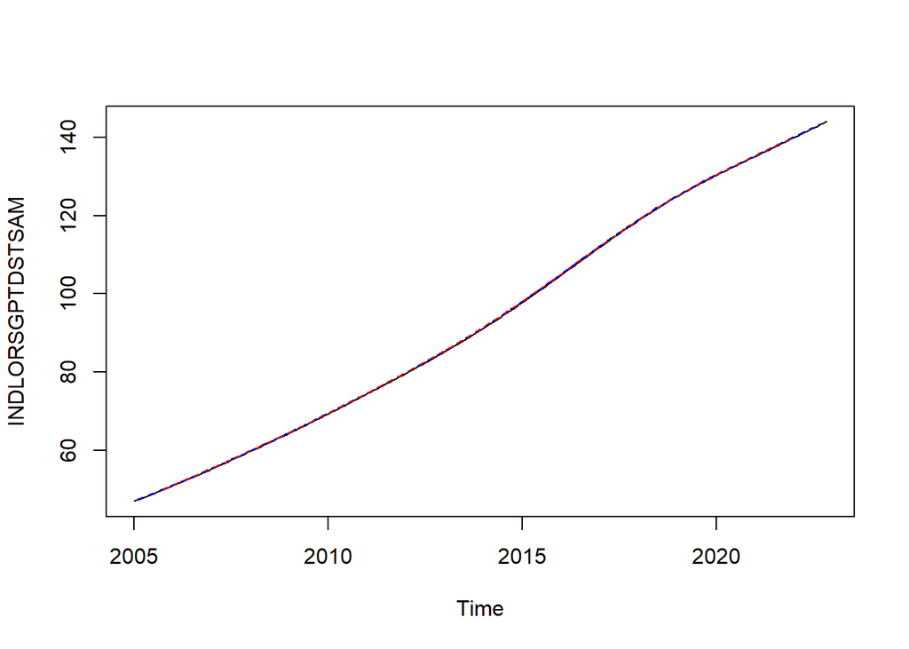

```r
f_trend <- filter(trend_szereg, sides = 2, filter = rep(1/4,4))
f2_trend <- filter(trend_szereg, sides = 2, filter = rep(1/20,20))
plot(trend_szereg)
lines(f_trend, col = "blue", lty=2)
lines(f2_trend, col = "red", lty=2)
```

## **3.3 Dekompozycja za podstawie modelu regresji**

#### **3.3.1 Trend liniowy**

#### **Szereg czasowy z sezonowością i trendem**

#### Trend liniowy

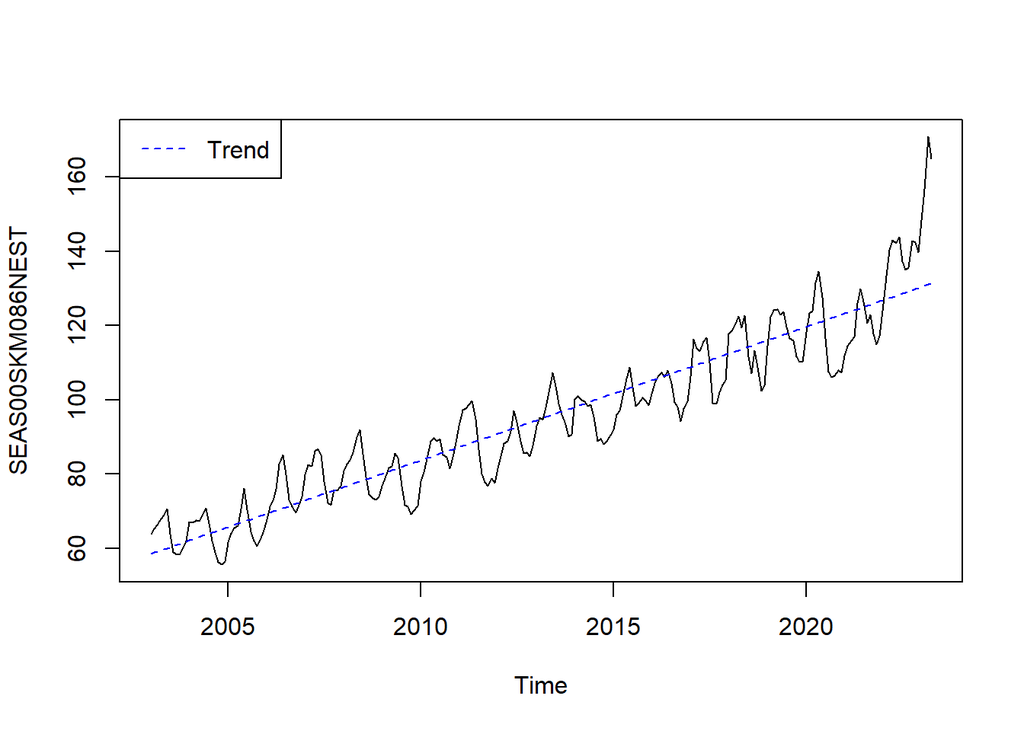

```r
trendliniowy <- tslm(sz1 ~ trend)
plot(sz1)
lines(fitted(trendliniowy), col = "blue", lty = 2)
legend("topleft",c("Trend"), col = c("blue"), lty = 2)
```

#### Trend liniowy z sezonowością

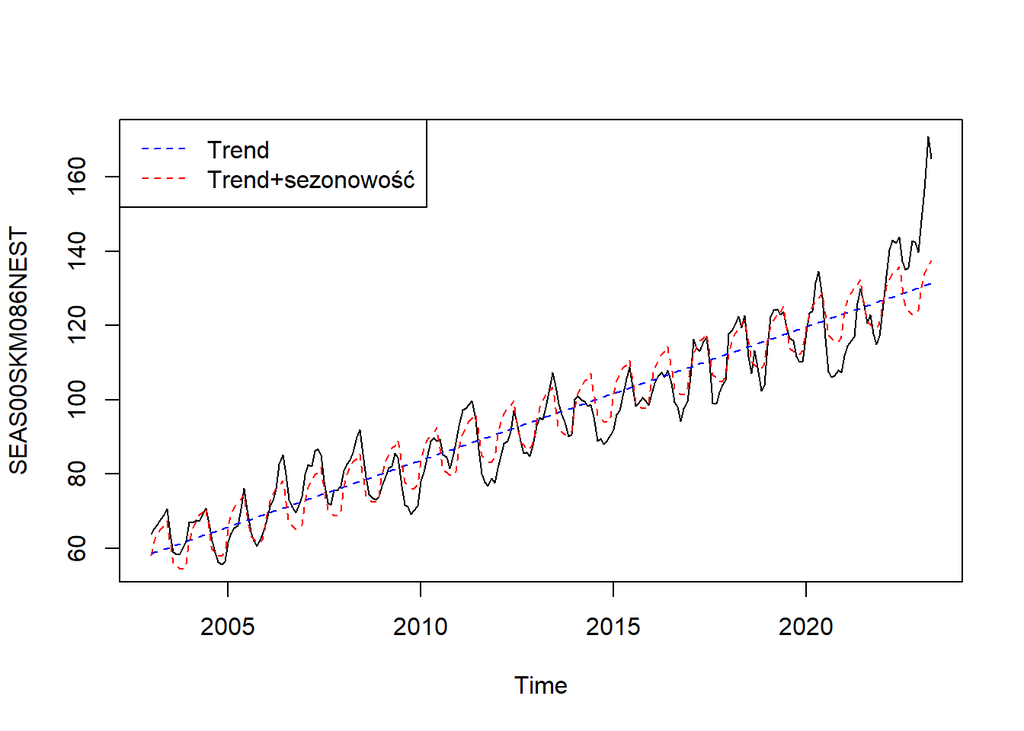

```r
trendisez <- tslm(sz1 ~ trend + season)
plot(sz1)
lines(fitted(trendliniowy), col = "blue", lty = 2)
lines(fitted(trendisez), col = "red", lty = 2)
legend("topleft",c("Trend", "Trend+sezonowość"), col = c("blue", "red"), lty = 2)
```

#### Trend liniowy z sezonowością i Box-Cox.

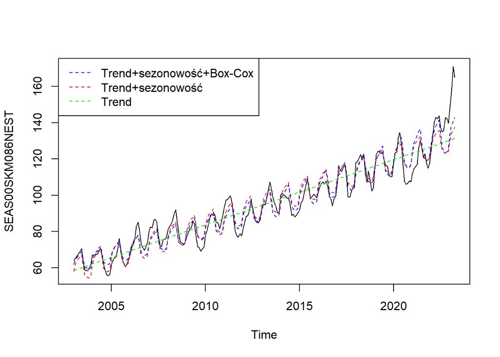

```r
liniowybox1 <- tslm(sz1 ~ poly(trend, raw=TRUE, degree = 1))
liniowybox2 <- tslm(sz1 ~ poly(trend, raw=TRUE, degree = 1) + season)
liniowybox3 <- tslm(sz1 ~ poly(trend, raw=TRUE, degree = 1) + season, lambda = "auto")
plot(sz1)
lines(fitted(liniowybox1), col="green", lty=2)
lines(fitted(liniowybox2), col="red", lty=2)
lines(fitted(liniowybox3), col="blue", lty=2)
legend("topleft",c("Trend+sezonowość+Box-Cox", "Trend+sezonowość", "Trend"), col = c("blue", "red", "green"), lty = 2)
```

#### **Szereg czasowy z trendem**

#### Trend liniowy

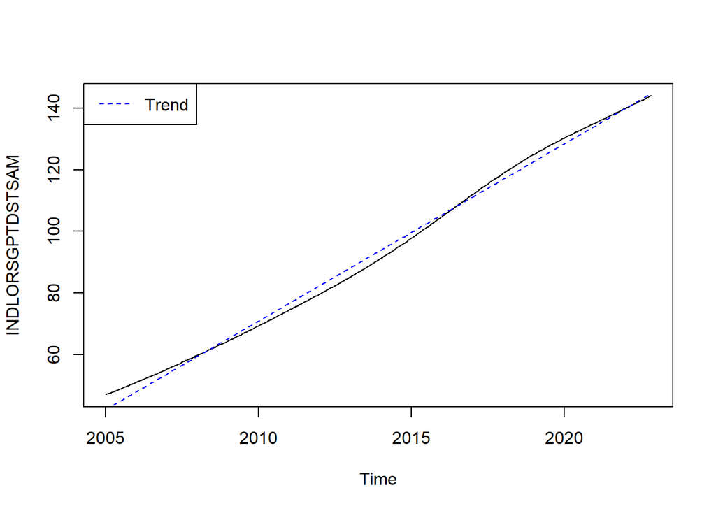

```r
trendliniowy_trend <- tslm(trend_szereg ~ trend)
plot(trend_szereg)
lines(fitted(trendliniowy_trend), col = "blue", lty = 2)
legend("topleft",c("Trend"), col = c("blue"), lty = 2)
```

#### Trend liniowy z sezonowością

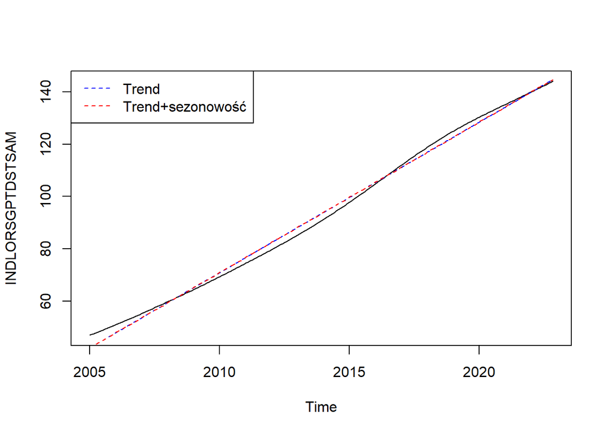

```r
trendisez_trend <- tslm(trend_szereg ~ trend + season)
plot(trend_szereg)
lines(fitted(trendliniowy_trend), col = "blue", lty = 2)
lines(fitted(trendisez_trend ), col = "red", lty = 2)
legend("topleft",c("Trend", "Trend+sezonowość"), col = c("blue", "red"), lty = 2)
```

#### Trend liniowy z sezonowością i Box-Cox.

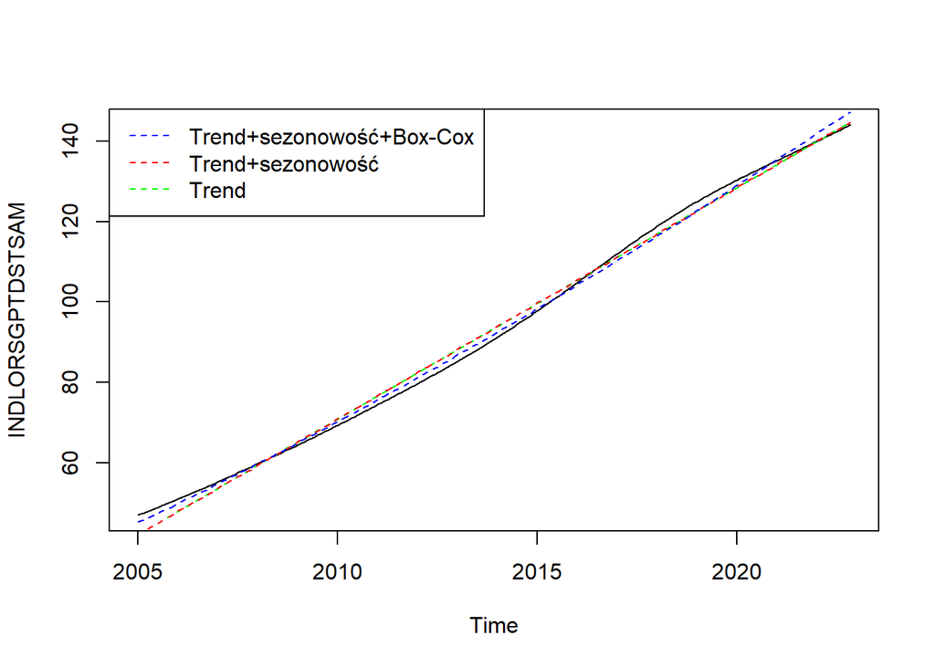

```r
liniowybox1_trend <- tslm(trend_szereg ~ poly(trend, raw=TRUE, degree = 1))
liniowybox2_trend <- tslm(trend_szereg ~ poly(trend, raw=TRUE, degree = 1) + season)
liniowybox3_trend <- tslm(trend_szereg ~ poly(trend, raw=TRUE, degree = 1) + season, lambda = "auto")
plot(trend_szereg)
lines(fitted(liniowybox1_trend), col="green", lty=2)
lines(fitted(liniowybox2_trend), col="red", lty=2)
lines(fitted(liniowybox3_trend), col="blue", lty=2)
legend("topleft",c("Trend+sezonowość+Box-Cox", "Trend+sezonowość", "Trend"), col = c("blue", "red", "green"), lty = 2)
```

#### **3.3.2 Trend wielomianowy 2 stopnia**

#### Trend wielomianowy z sezonowością i Box-Cox.

#### **Szereg czasowy z sezonowością i trendem**

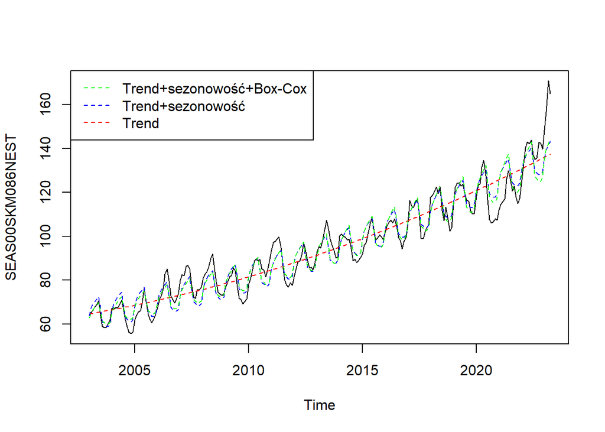

```r
w2box1 <- tslm(sz1 ~ poly(trend, raw=TRUE, degree = 2))
w2box2 <- tslm(sz1 ~ poly(trend, raw=TRUE, degree = 2) + season)
w2box3 <- tslm(sz1 ~ poly(trend, raw=TRUE, degree = 2) + season, lambda = "auto")
plot(sz1)
lines(fitted(w2box1), col="red", lty=2)
lines(fitted(w2box2), col="blue", lty=2)
lines(fitted(w2box3), col="green", lty=2)
legend("topleft",c("Trend+sezonowość+Box-Cox", "Trend+sezonowość", "Trend"), col = c("green", "blue", "red"), lty = 2)
```

#### **Szereg czasowy z trendem**

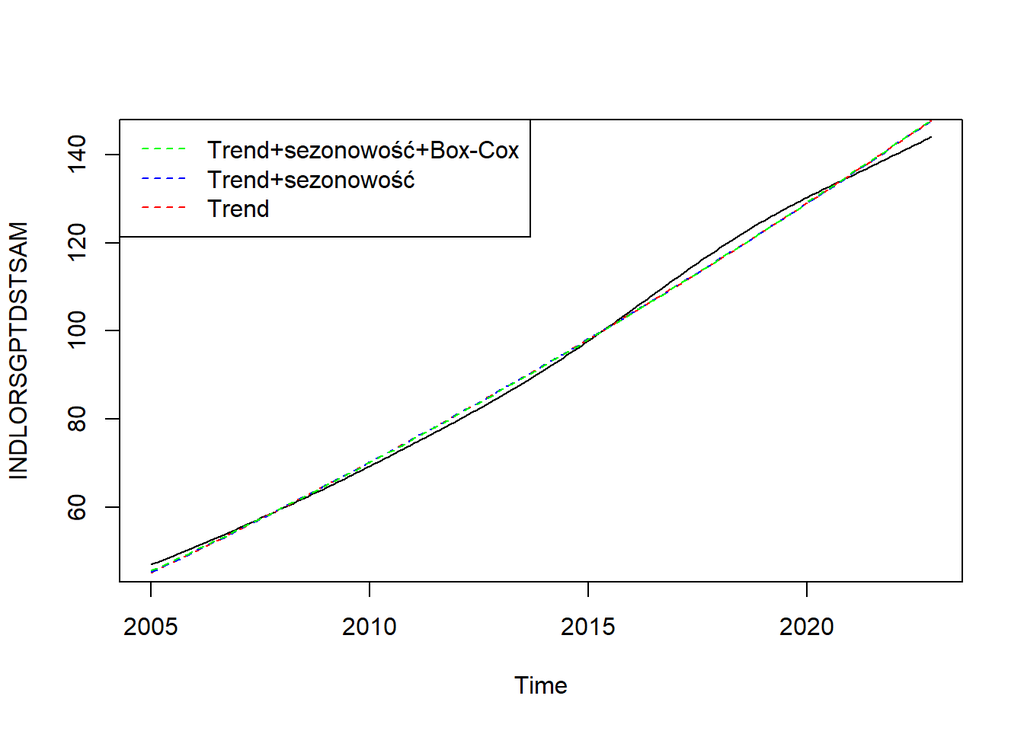

```r
w2box1_trend <- tslm(trend_szereg ~ poly(trend, raw=TRUE, degree = 2))
w2box2_trend <- tslm(trend_szereg ~ poly(trend, raw=TRUE, degree = 2) + season)
w2box3_trend <- tslm(trend_szereg ~ poly(trend, raw=TRUE, degree = 2) + season, lambda = "auto")
plot(trend_szereg)
lines(fitted(w2box1_trend), col="red", lty=2)
lines(fitted(w2box2_trend), col="blue", lty=2)
lines(fitted(w2box3_trend), col="green", lty=2)
legend("topleft",c("Trend+sezonowość+Box-Cox", "Trend+sezonowość", "Trend"), col = c("green", "blue", "red"), lty = 2)
```

#### **3.3.2 Trend wielomianowy 3 stopnia**

#### Trend wielomianowy z sezonowością i Box-Cox.

#### **Szereg czasowy z sezonowością i trendem**

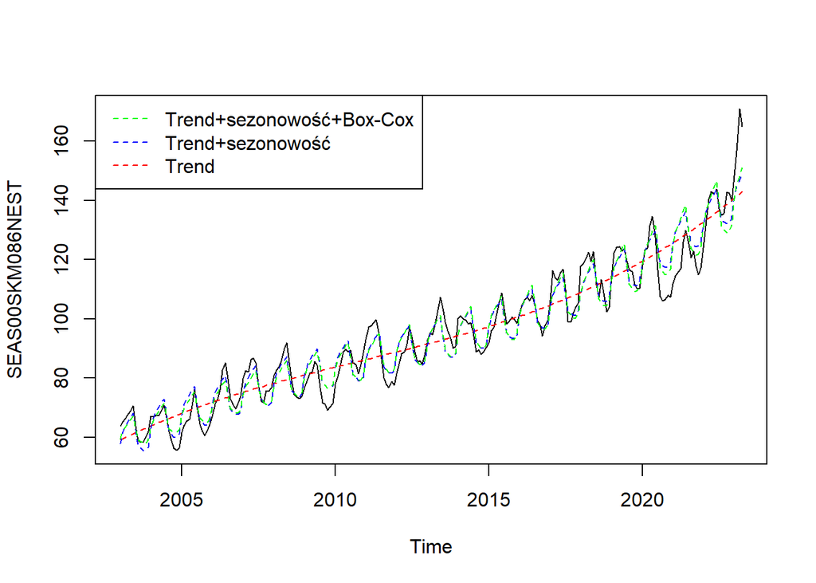

```r
w3box1 <- tslm(sz1 ~ poly(trend, raw=TRUE, degree = 3))
w3box2 <- tslm(sz1 ~ poly(trend, raw=TRUE, degree = 3) + season)
w3box3 <- tslm(sz1 ~ poly(trend, raw=TRUE, degree = 3) + season, lambda = "auto")
plot(sz1)
lines(fitted(w3box1), col="red", lty=2)
lines(fitted(w3box2), col="blue", lty=2)
lines(fitted(w3box3), col="green", lty=2)
legend("topleft",c("Trend+sezonowość+Box-Cox", "Trend+sezonowość", "Trend"), col = c("green", "blue", "red"), lty = 2)
```

#### **Szereg czasowy z trendem**

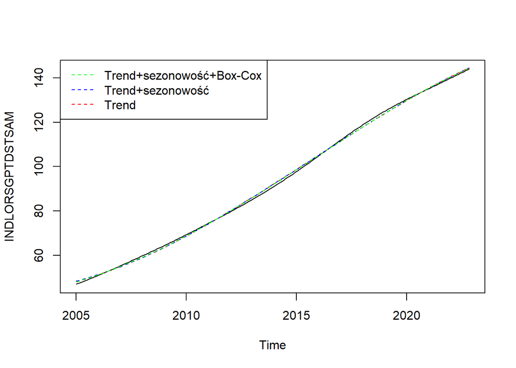

```r
w3box1_trend <- tslm(trend_szereg ~ poly(trend, raw=TRUE, degree = 3))
w3box2_trend <- tslm(trend_szereg ~ poly(trend, raw=TRUE, degree = 3) + season)
w3box3_trend <- tslm(trend_szereg ~ poly(trend, raw=TRUE, degree = 3) + season, lambda = "auto")
plot(trend_szereg)
lines(fitted(w3box1_trend), col="red", lty=2)
lines(fitted(w3box2_trend), col="blue", lty=2)
lines(fitted(w3box3_trend), col="green", lty=2)
legend("topleft",c("Trend+sezonowość+Box-Cox", "Trend+sezonowość", "Trend"), col = c("green", "blue", "red"), lty = 2)
```

## **4. Eliminacja trendu i sezonowości**

#### **Szereg czasowy z sezonowością i trendem**

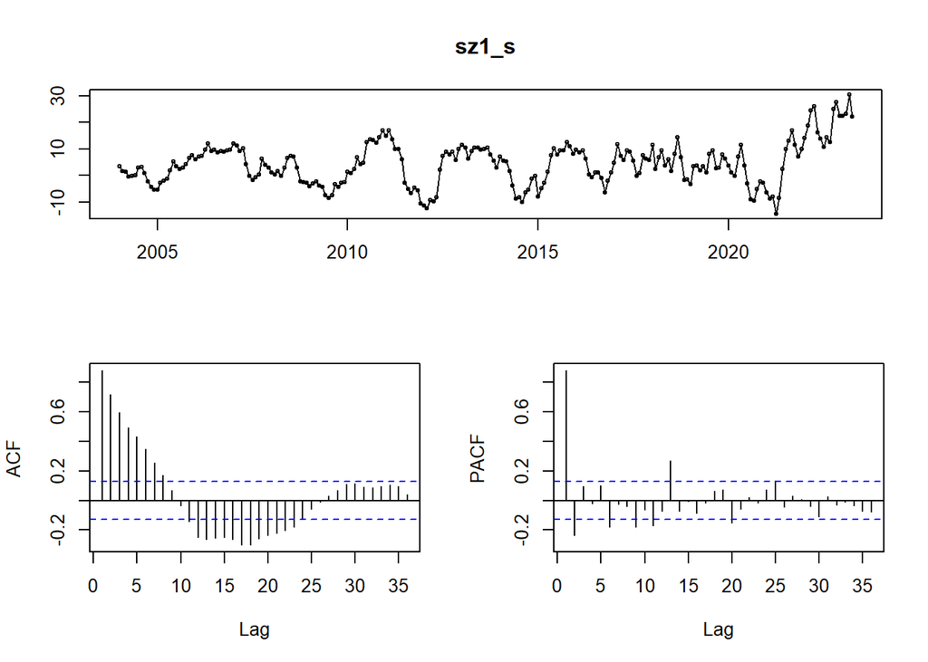

```r
sz1_s <- diff(sz1, lag = 12)
tsdisplay(sz1_s)
```

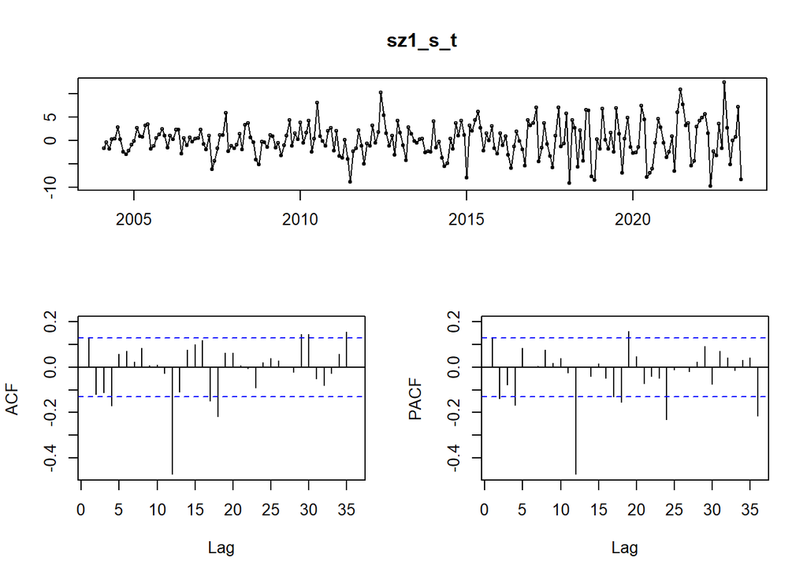

```r
sz1_s_t <- diff(sz1_s, lag = 1)
tsdisplay(sz1_s_t)
```

#### **Szereg czasowy z trendem**

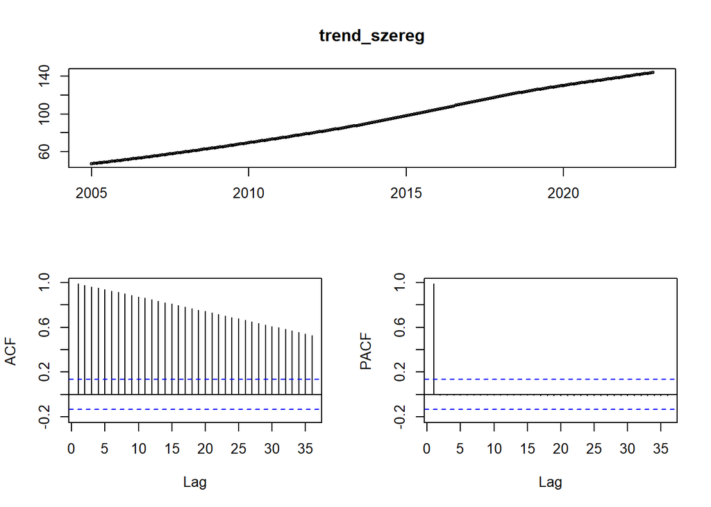

```r
tre_sez <- diff(trend_szereg, lag = 12)
tsdisplay(trend_szereg)
```

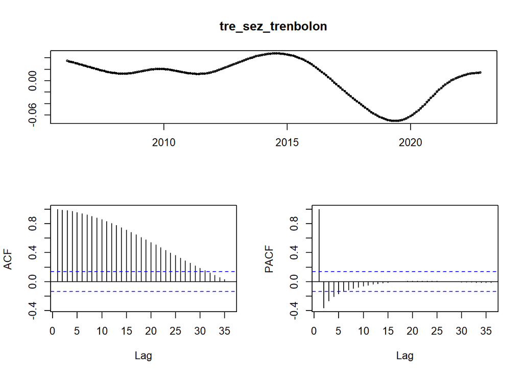

```r
tre_sez_trenbolon <- diff(tre_sez, lag = 1)
tsdisplay(tre_sez_trenbolon)
```

## **5 Uczynienie szeregów stacjonarnymi, sprawdzenie czy są one realizacją szumu białego**

#### **5.1 Uczynienie szeregów stacjonarnymi**

#### **Szereg czasowy z sezonowością i trendem**

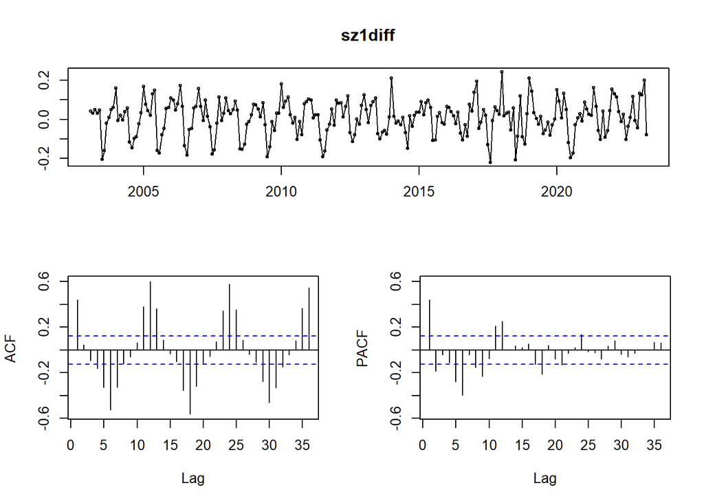

```r
lamb.auto <- BoxCox.lambda(sz1)
eL <- BoxCox(sz1, lambda = lamb.auto)
sz1diff <- diff(eL, lag = 1)
tsdisplay(sz1diff)
```

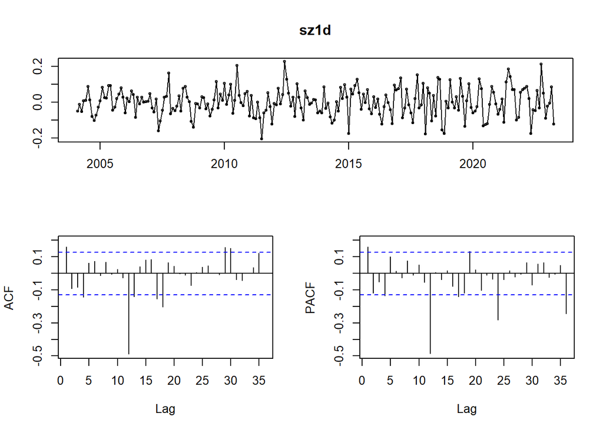

```r
sz1d <- diff(sz1diff, lag = 12)
tsdisplay(sz1d)
```

#### **Szereg czasowy z trendem**

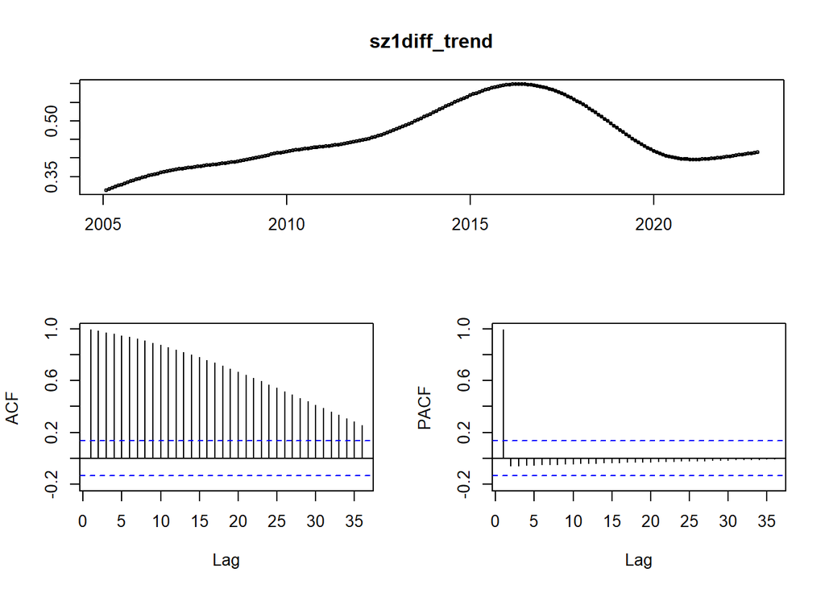

```r
lamb.auto_trend <- BoxCox.lambda(trend_szereg)
eL_trend <- BoxCox(trend_szereg, lambda = lamb.auto_trend)
sz1diff_trend <- diff(trend_szereg, lag = 1)
tsdisplay(sz1diff_trend)
```

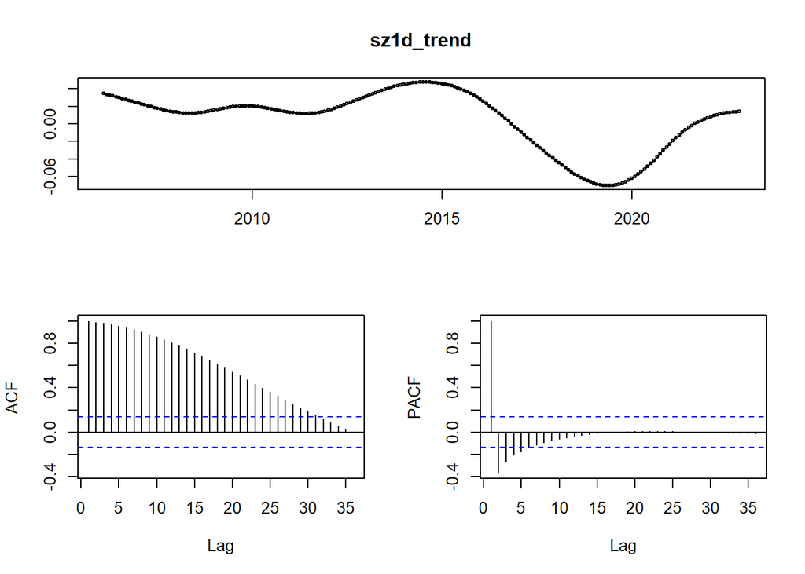

```r
sz1d_trend <- diff(sz1diff_trend, lag = 12)
tsdisplay(sz1d_trend)
```

#### **5.2 Sprawdzenie czy szeregi są realizacją szumu białego**

#### **Szereg czasowy z sezonowością i trendem**

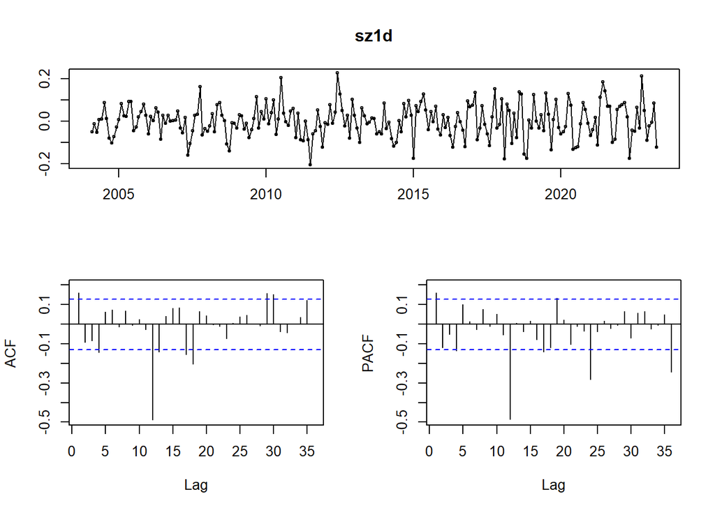

```r
tsdisplay(sz1d)
```

#### Odp: Szereg nie jest realizacją szumu białego, ponieważ wartości ACF oraz PACF nie mieszczą się w przedziałach ufności.

#### **Szereg czasowy z trendem**

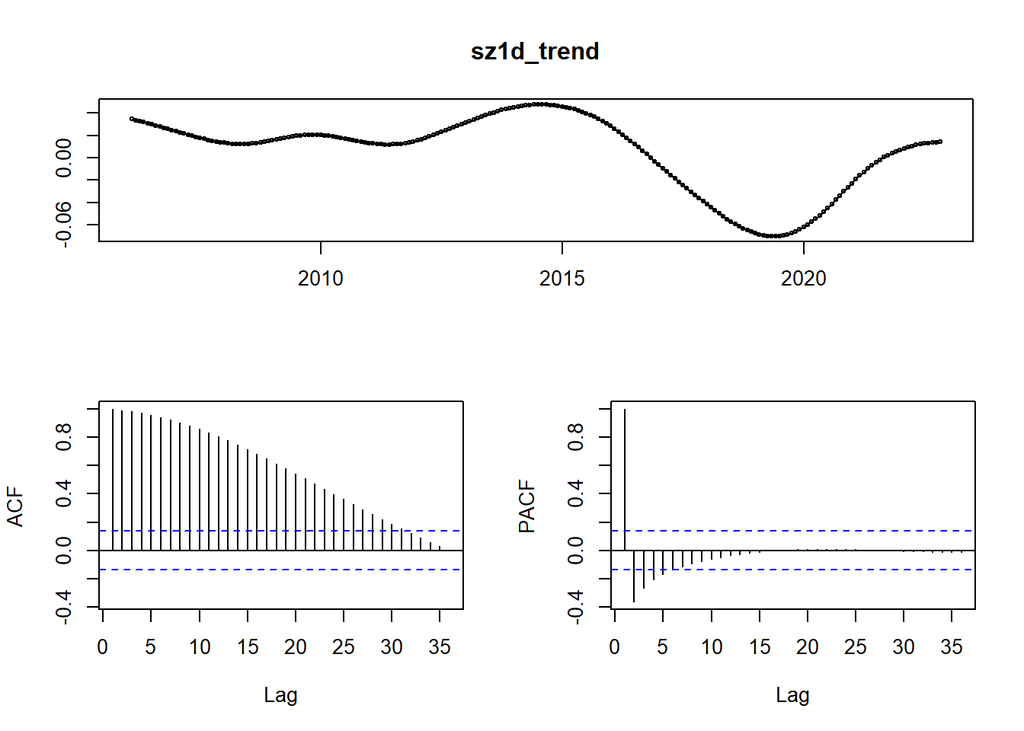

```r
tsdisplay(sz1d_trend)
```

#### Odp: Szereg nie jest realizacją szumu białego, ponieważ wartości ACF oraz PACF nie mieszczą się w przedziałach ufności.

#### **5.3 Sprawdzenie, które wartości AF oraz MA warto wziąć pod uwagę.**

#### **Szereg czasowy z sezonowością i trendem**

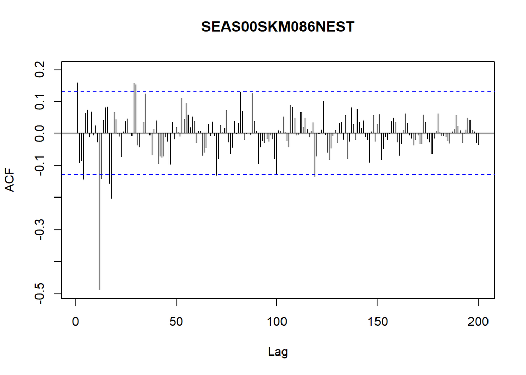

```r
Acf(sz1d, lag.max = 200)
```

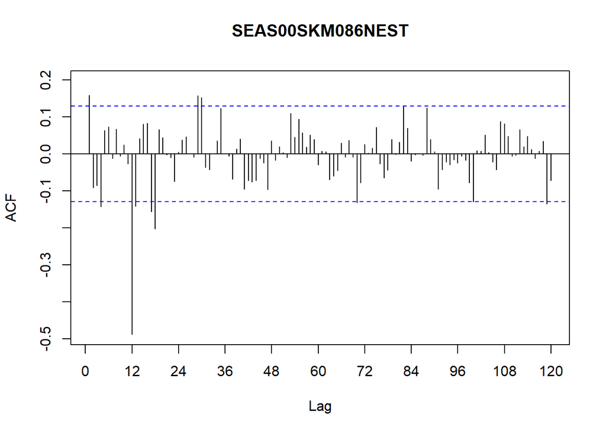

```r
Acf(sz1d, lag.max = 120)
```

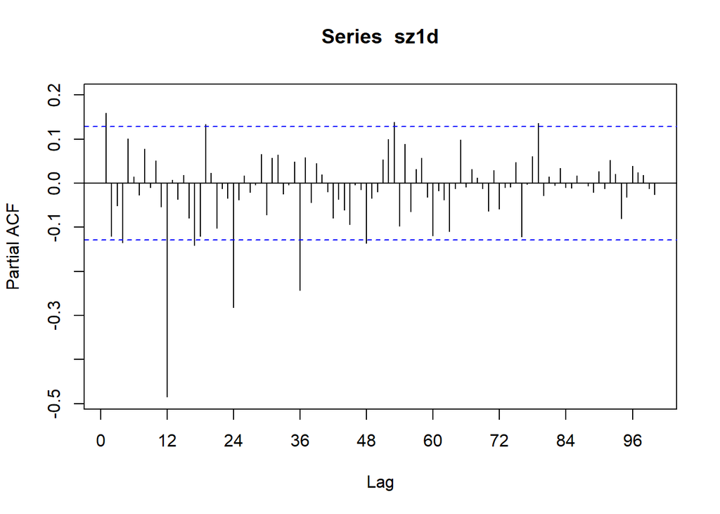

```r
Pacf(sz1d, lag.max = 100)
```

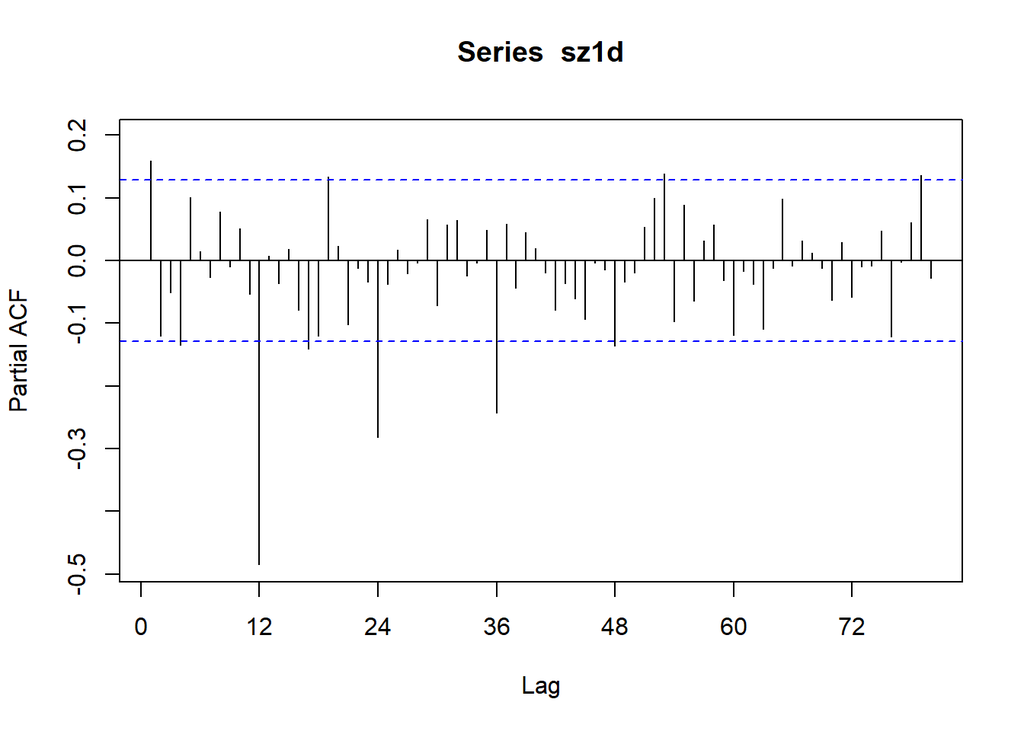

```r
Pacf(sz1d, lag.max = 80)
```

#### Odp: Warto wziąć pod uwagę wartości AR(12), AR(24), AR(36), AR(79) a także MA(12), MA(18), MA(119).

#### **Szereg czasowy z trendem**

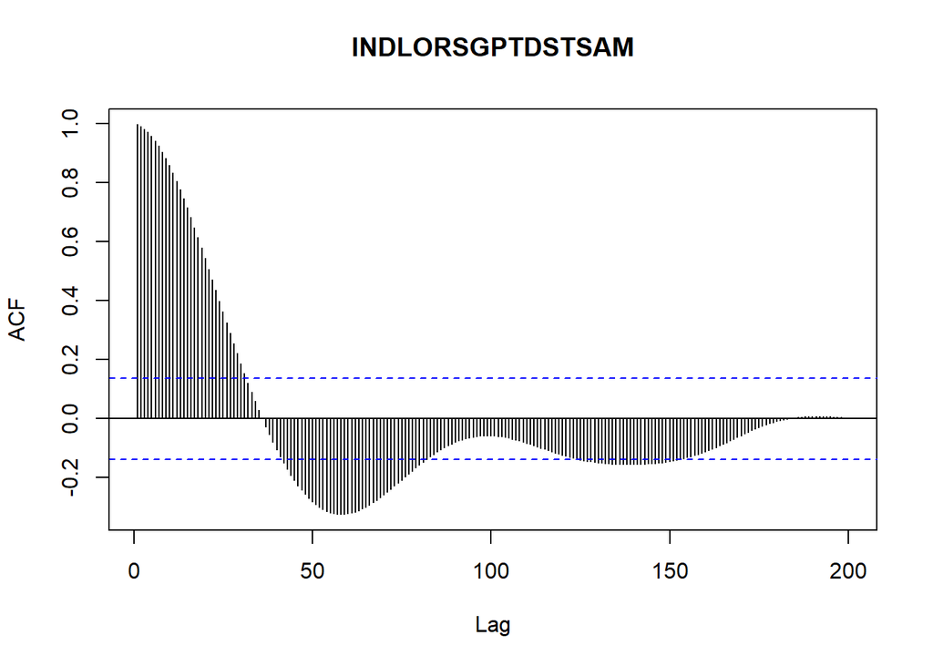

```r
Acf(sz1d_trend, lag.max = 200)
```

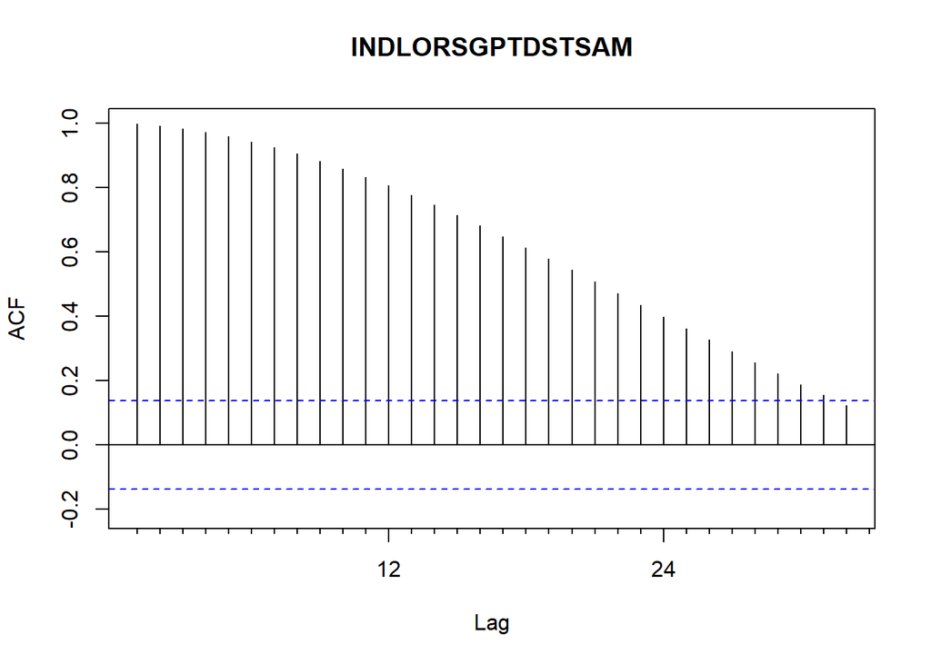

```r
Acf(sz1d_trend, lag.max = 32)
```

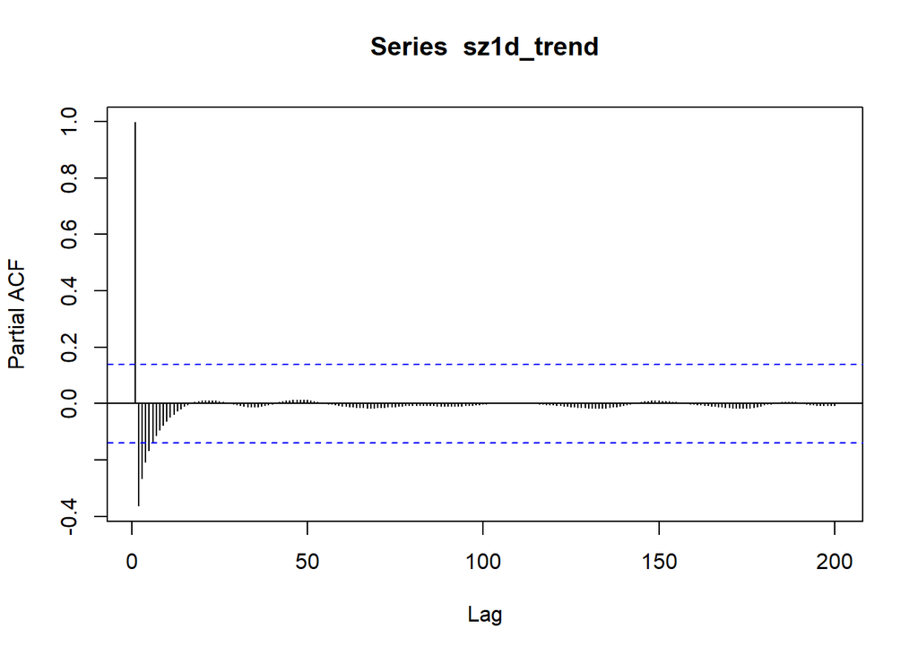

```r
Pacf(sz1d_trend, lag.max = 200)
```

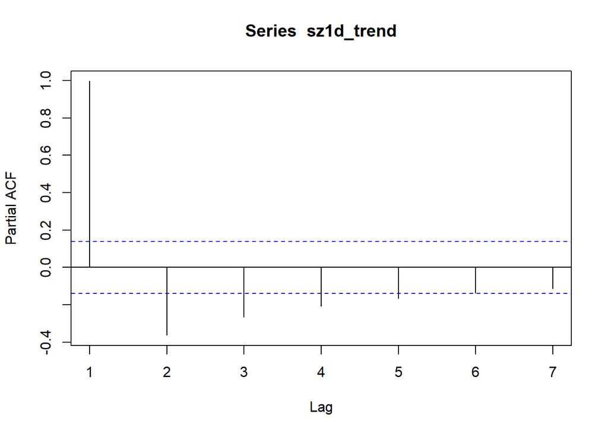

```r
Pacf(sz1d_trend, lag.max = 7)
```

#### Odp: Warto wziąć pod uwagę wartości AR(6) a także MA(30).

## **6. Wyznaczenie współczynników modelu AR, porównanie dopasowania z wykorzystaniem różnych metod estymacji, automatycznie dobrana wartość rzędu oraz wyznaczenie wartości MA**

#### **6.1 Estymacja**

#### **6.1.1 Automatyczne przypasowanie (aic=TRUE)**

#### **Szereg czasowy z sezonowością i trendem**

```r
automatyczne <- ar(sz1d, aic = TRUE)
automatyczne
```

```
##
## Call:
## ar(x = sz1d, aic = TRUE)
##
## Coefficients:
##       1        2        3        4        5        6        7        8
##  0.1581  -0.0961  -0.0317  -0.1012   0.0689   0.0589  -0.0037   0.0151
##       9       10       11       12
## -0.0349  -0.0002   0.0355  -0.4847
##
## Order selected 12  sigma^2 estimated as  0.00446
```

#### **Szereg czasowy z trendem**

```r
automatyczne_trend <- ar(sz1d_trend, aic = TRUE)
automatyczne_trend
```

```
##
## Call:
## ar(x = sz1d_trend, aic = TRUE)
##
## Coefficients:
##       1        2        3        4        5        6        7
##  1.1344  -0.0058  -0.0061  -0.0065  -0.0068  -0.0070  -0.1128
##
## Order selected 7  sigma^2 estimated as  5.879e-06
```

#### **6.1.2 Metoda Yule-Walker**

#### **Szereg czasowy z sezonowością i trendem**

```r
yulewalker <- ar(sz1d, aic = FALSE, order.max = 12, method = 'yule-walker')
yulewalker
```

```
##
## Call:
## ar(x = sz1d, aic = FALSE, order.max = 12, method = "yule-walker")
##
## Coefficients:
##       1        2        3        4        5        6        7        8
##  0.1581  -0.0961  -0.0317  -0.1012   0.0689   0.0589  -0.0037   0.0151
##       9       10       11       12
## -0.0349  -0.0002   0.0355  -0.4847
##
## Order selected 12  sigma^2 estimated as  0.00446
```

#### **Szereg czasowy z trendem**

```r
yulewalker_trend <- ar(sz1d_trend, aic = FALSE, order.max = 6, method = 'yule-walker')
yulewalker_trend
```

```
##
## Call:
## ar(x = sz1d_trend, aic = FALSE, order.max = 6, method = "yule-walker")
##
## Coefficients:
##       1        2        3        4        5        6
##  1.1498  -0.0051  -0.0055  -0.0059  -0.0062  -0.1367
##
## Order selected 6  sigma^2 estimated as  5.924e-06
```

#### Automatyczna funckcja doboru wybrała odpowiednio dla szeregu z sezonowością oraz trendem i szeregu z trendem modele rzędu 12 oraz 7. Jak można zauważyć wartości dla atumatycznego doboru jak i dla metody Yule-Walker’a w przypadku szeregu **sz1d** są identyczne. Natomiast w przypadku dla szeregu **sz1d_trend** również są one do siebie zbliżone pomimo doboru innych rzędów.

#### **6.2 Wyznaczenie wartości MA**

#### **Szereg czasowy z sezonowością i trendem**

```r
sz1darima <- Arima(sz1d, order = c(0,0,12))
summary(sz1darima)
```

```
## Series: sz1d
## ARIMA(0,0,12) with non-zero mean
##
## Coefficients:
##          ma1      ma2      ma3      ma4     ma5     ma6     ma7      ma8
##       0.0420  -0.0195  -0.0587  -0.0428  0.0298  0.0720  0.0424  -0.0312
## s.e.  0.0747   0.0567   0.0468   0.0626  0.0786  0.0887  0.0697   0.0495
##           ma9     ma10    ma11     ma12   mean
##       -0.0883  -0.0530  0.0336  -0.9217  4e-04
## s.e.   0.0507   0.0592  0.0683   0.0833  6e-04
##
## sigma^2 = 0.003052:  log likelihood = 332.72
## AIC=-637.45   AICc=-635.5   BIC=-589.25
##
## Training set error measures:
##                         ME       RMSE        MAE      MPE     MAPE      MASE
## Training set -0.0003874277 0.05366609 0.04162007 17.17066 160.1966 0.3889861
##                   ACF1
## Training set 0.1178095
```

#### **Szereg czasowy z trendem**

```r
sz1darima_trend <- Arima(sz1d_trend, order = c(0,0,1))
summary(sz1darima_trend)
```

```
## Series: sz1d_trend
## ARIMA(0,0,1) with non-zero mean
##
## Coefficients:
##          ma1    mean
##       1.0000  0.0048
## s.e.  0.0122  0.0023
##
## sigma^2 = 0.000281:  log likelihood = 537.6
## AIC=-1069.2   AICc=-1069.08   BIC=-1059.27
##
## Training set error measures:
##                         ME       RMSE        MAE      MPE     MAPE      MASE
## Training set -4.697906e-05 0.01668132 0.01325377 1223.559 1229.368 0.8094941
##                   ACF1
## Training set 0.9929186
```

## **7. Wyznaczenie optymalnych modeli z wykorzystaniem funkcji auto.arima() oraz wyznaczenie ich współczynników.**

#### **Szereg czasowy z sezonowością i trendem**

```r
auto11 <- auto.arima(sz1d, ic = 'aic')
summary(auto11)
```

```
## Series: sz1d
## ARIMA(0,0,1)(0,0,2)[12] with zero mean
##
## Coefficients:
##          ma1     sma1    sma2
##       0.1893  -0.9590  0.0946
## s.e.  0.0727   0.0764  0.0767
##
## sigma^2 = 0.003137:  log likelihood = 330.66
## AIC=-653.31   AICc=-653.14   BIC=-639.54
##
## Training set error measures:
##                       ME       RMSE        MAE      MPE     MAPE      MASE
## Training set 0.001699836 0.05564503 0.04228474 4.345287 183.6709 0.3951982
##                     ACF1
## Training set -0.01740148
```

```r
auto22 <- auto.arima(sz1d, ic = 'aicc')
summary(auto22)
```

```
## Series: sz1d
## ARIMA(0,0,1)(0,0,2)[12] with zero mean
##
## Coefficients:
##          ma1     sma1    sma2
##       0.1893  -0.9590  0.0946
## s.e.  0.0727   0.0764  0.0767
##
## sigma^2 = 0.003137:  log likelihood = 330.66
## AIC=-653.31   AICc=-653.14   BIC=-639.54
##
## Training set error measures:
##                       ME       RMSE        MAE      MPE     MAPE      MASE
## Training set 0.001699836 0.05564503 0.04228474 4.345287 183.6709 0.3951982
##                     ACF1
## Training set -0.01740148
```

```r
auto33 <- auto.arima(sz1d, ic = 'bic')
summary(auto33)
```

```
## Series: sz1d
## ARIMA(0,0,0)(0,0,1)[12] with zero mean
##
## Coefficients:
##          sma1
##       -0.8746
## s.e.   0.0497
##
## sigma^2 = 0.00323:  log likelihood = 326.49
## AIC=-648.99   AICc=-648.94   BIC=-642.1
##
## Training set error measures:
##                       ME       RMSE        MAE      MPE     MAPE     MASE
## Training set 0.001999026 0.05670901 0.04363907 10.41961 182.5122 0.407856
##                   ACF1
## Training set 0.1466456
```

#### Odp: Optymalny model z wartościami: ARIMA(0,0,1)(0,0,2). Został on wyznaczony przez dwie pierwsze funkcje z parametrem ic równym ‘aic’ i ‘aicc’.

#### **Szereg czasowy z trendem**

```r
auto11_trend <- auto.arima(sz1d_trend, ic = 'aic')
summary(auto11_trend)
```

```
## Series: sz1d_trend
## ARIMA(4,2,2)(0,0,2)[12]
##
## Coefficients:
##          ar1      ar2     ar3      ar4     ma1     ma2     sma1    sma2
##       2.5984  -2.4666  1.1017  -0.2365  0.5176  0.4867  -1.1079  0.2172
## s.e.  0.0141   0.0283  0.0143   0.0002  0.0156  0.0068   0.0003  0.0003
##
## sigma^2 = 1.467e-11:  log likelihood = 2437.94
## AIC=-4857.87   AICc=-4856.92   BIC=-4828.19
##
## Training set error measures:
##                         ME         RMSE          MAE       MPE      MAPE
## Training set -5.382588e-08 3.734151e-06 1.141153e-06 0.7330421 0.7392366
##                      MASE       ACF1
## Training set 6.969765e-05 -0.4898354
```

```r
auto22_trend <- auto.arima(sz1d_trend, ic = 'aicc')
summary(auto22_trend)
```

```
## Series: sz1d_trend
## ARIMA(4,2,2)(0,0,2)[12]
##
## Coefficients:
##          ar1      ar2     ar3      ar4     ma1     ma2     sma1    sma2
##       2.5984  -2.4666  1.1017  -0.2365  0.5176  0.4867  -1.1079  0.2172
## s.e.  0.0141   0.0283  0.0143   0.0002  0.0156  0.0068   0.0003  0.0003
##
## sigma^2 = 1.467e-11:  log likelihood = 2437.94
## AIC=-4857.87   AICc=-4856.92   BIC=-4828.19
##
## Training set error measures:
##                         ME         RMSE          MAE       MPE      MAPE
## Training set -5.382588e-08 3.734151e-06 1.141153e-06 0.7330421 0.7392366
##                      MASE       ACF1
## Training set 6.969765e-05 -0.4898354
```

```r
auto33_trend <- auto.arima(sz1d_trend, ic = 'bic')
summary(auto33_trend)
```

```
## Series: sz1d_trend
## ARIMA(4,2,2)(0,0,2)[12]
##
## Coefficients:
##          ar1      ar2     ar3      ar4     ma1     ma2     sma1    sma2
##       2.5984  -2.4666  1.1017  -0.2365  0.5176  0.4867  -1.1079  0.2172
## s.e.  0.0141   0.0283  0.0143   0.0002  0.0156  0.0068   0.0003  0.0003
##
## sigma^2 = 1.467e-11:  log likelihood = 2437.94
## AIC=-4857.87   AICc=-4856.92   BIC=-4828.19
##
## Training set error measures:
##                         ME         RMSE          MAE       MPE      MAPE
## Training set -5.382588e-08 3.734151e-06 1.141153e-06 0.7330421 0.7392366
##                      MASE       ACF1
## Training set 6.969765e-05 -0.4898354
```

#### Odp: Optymalny model z wartościami: ARIMA(4,2,2)(0,0,2). Został on wyznaczony przez wszystkie trzy funkcje z parametrem ic równym ‘aic’, ‘aicc’ i ‘bic’.

## **7. Prognozowanie metodami naiwnymi.**

#### **7.1 Szereg czasowy z sezonowością i trendem**

#### **7.1.1 Oparte na średniej - okres 24 miesiące.**

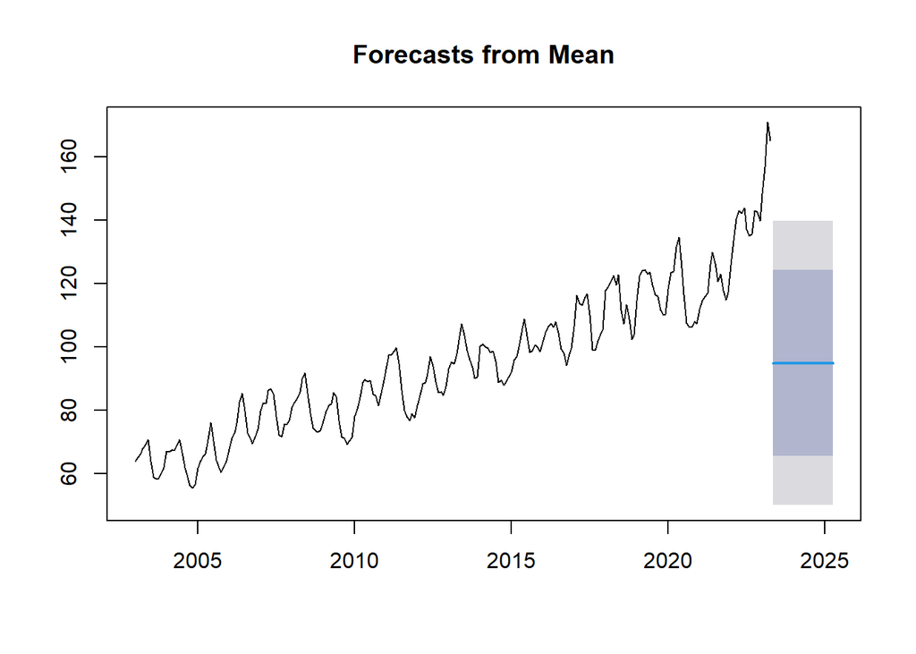

```r
sz1d.meanf <- meanf(sz1, h = 24)
plot(sz1d.meanf)
```

#### **7.1.2 Naive()**

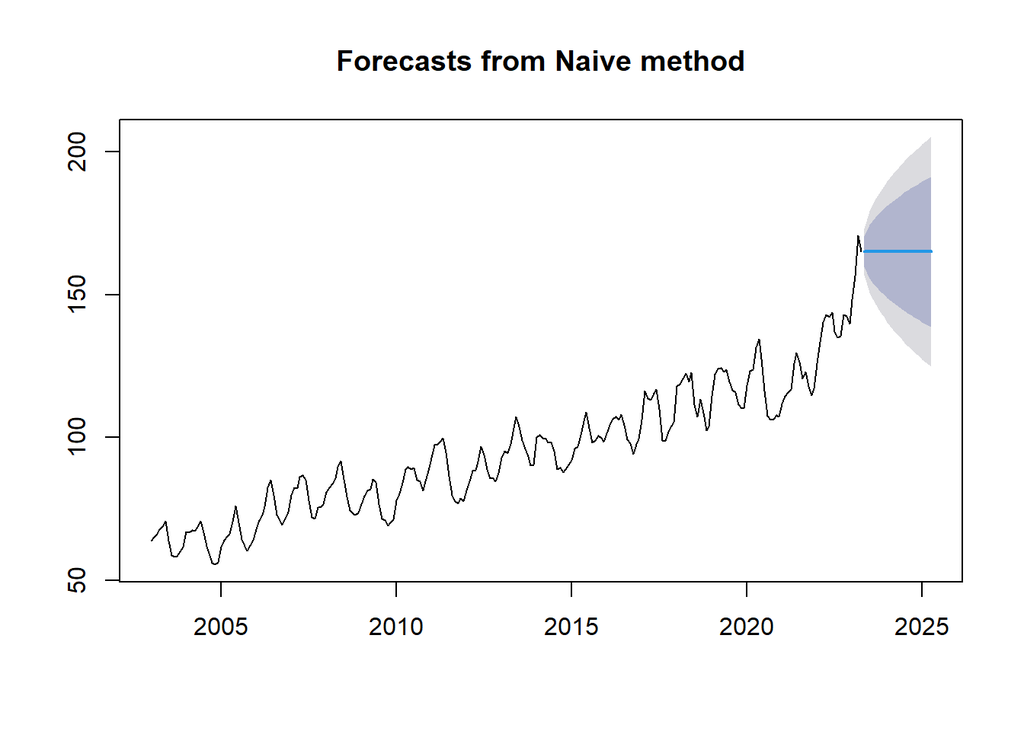

```r
naiwne <- naive(sz1, h =24)
plot(naiwne)
```

#### **7.1.3 Snaive()**

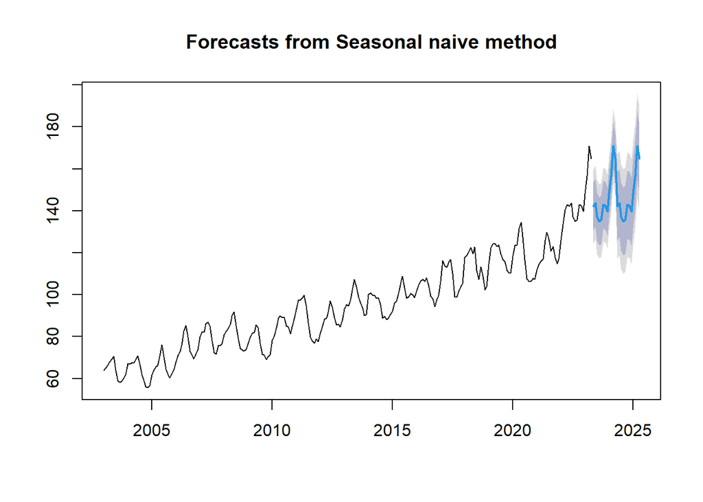

```r
snaiwne <- snaive(sz1, h=24)
plot(snaiwne)
```

#### **7.1.4 Z dryftem**

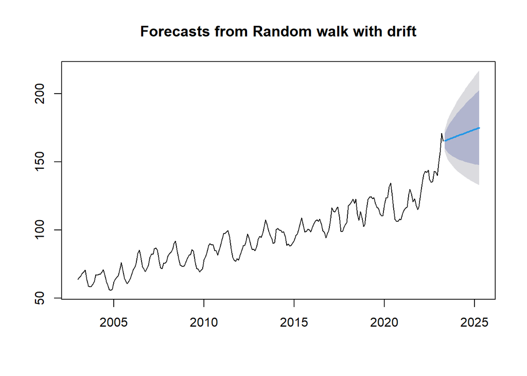

```r
zdriftem <- rwf(sz1, h=24, drift = TRUE)
plot(zdriftem)
```

#### **7.2 Szereg czasowy z trendem**

#### **7.2.1 Oparte na średniej - okres 24 miesiące.**

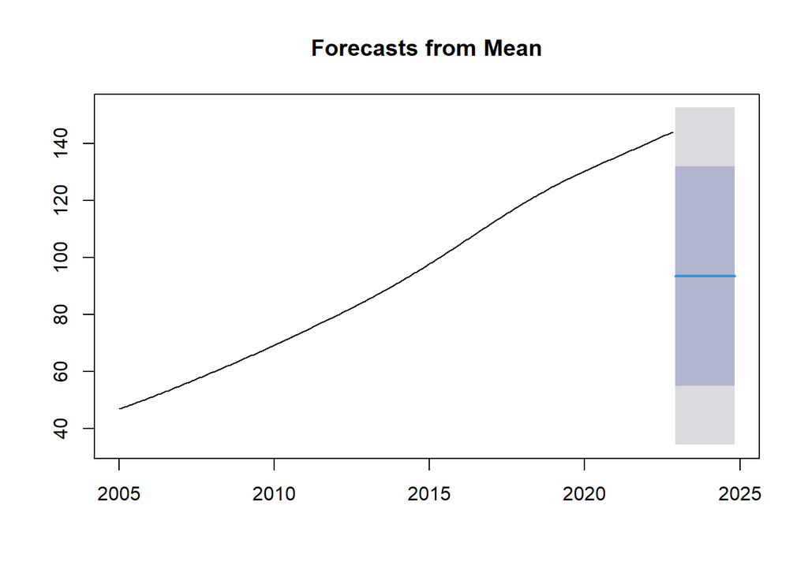

```r
sz1d.meanf_trend <- meanf(trend_szereg, h = 24)
plot(sz1d.meanf_trend)
```

#### **7.2.2 Naive()**

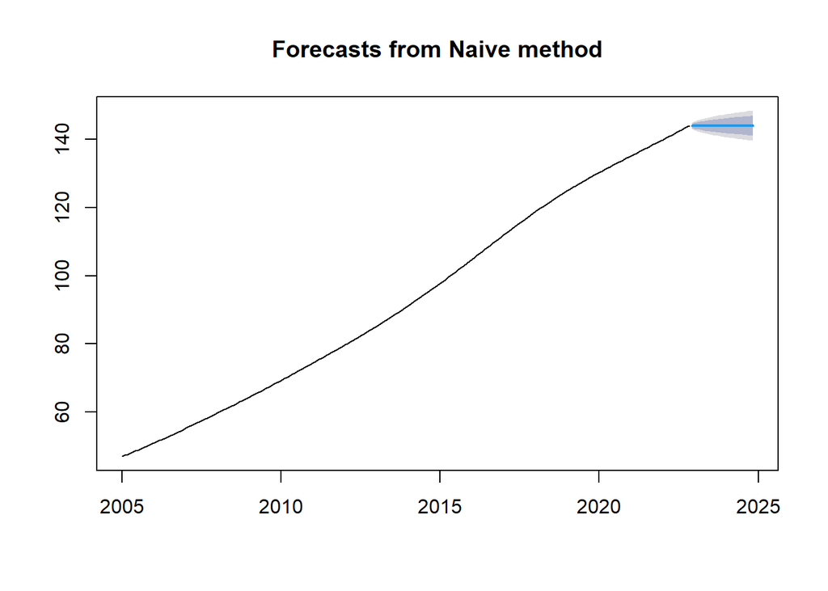

```r
naiwne_t <- naive(trend_szereg, h =24)
plot(naiwne_t)
```

#### **7.2.3 Snaive()**

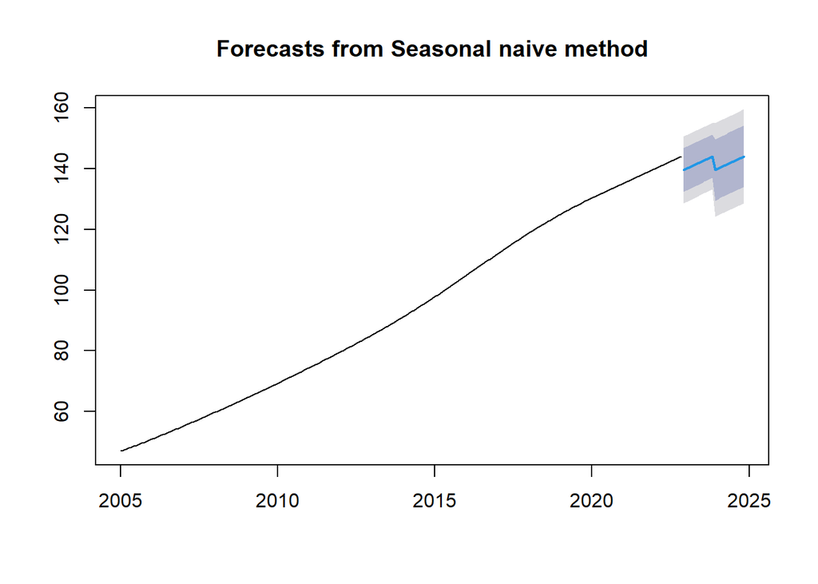

```r
snaiwne_t <- snaive(trend_szereg, h=24)
plot(snaiwne_t)
```

#### **7.2.4 Z dryftem**

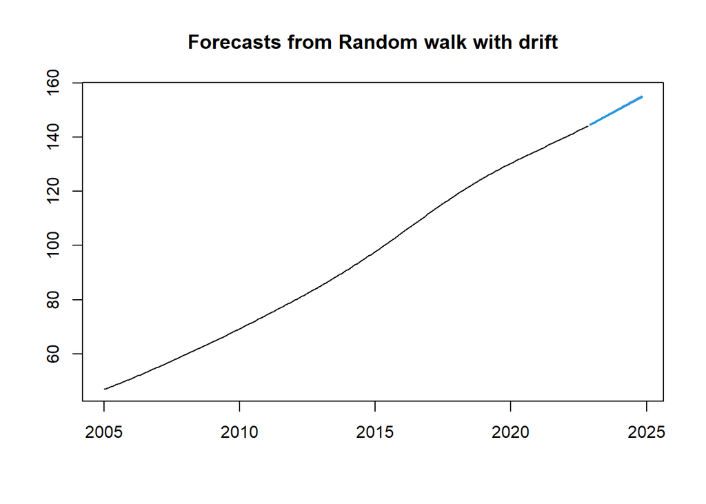

```r
zdriftem_trend <- rwf(trend_szereg, h=24, drift = TRUE)
plot(zdriftem_trend)
```

#### **7.3 Znalezienie najlepszej metody prognozowania**

#### **7.3.1 Szereg czasowy z sezonowością i trendem**

```r
(accuracy(sz1d.meanf))
```

```
##                        ME     RMSE      MAE       MPE     MAPE     MASE
## Training set -6.52802e-15 22.67122 18.46997 -5.787359 20.63471 2.582558
##                   ACF1
## Training set 0.9595869
```

```r
(accuracy(naiwne))
```

```
##                     ME     RMSE      MAE       MPE     MAPE      MASE      ACF1
## Training set 0.4163786 4.186172 3.256461 0.2973512 3.453553 0.4553338 0.4014227
```

```r
(accuracy(snaiwne))
```

```
##                    ME     RMSE     MAE      MPE     MAPE MASE      ACF1
## Training set 4.289741 8.985242 7.15181 3.920684 7.211238    1 0.8792765
```

```r
(accuracy(zdriftem))
```

```
##                         ME     RMSE      MAE        MPE     MAPE      MASE
## Training set -4.970404e-15 4.165413 3.193683 -0.1659126 3.391156 0.4465559
##                   ACF1
## Training set 0.4014227
```

#### **7.3.2 Szereg czasowy z trendem**

```r
(accuracy(sz1d.meanf_trend))
```

```
##                     ME     RMSE      MAE      MPE     MAPE     MASE      ACF1
## Training set 1.313e-15 29.83286 26.26348 -11.8096 32.34766 4.775015 0.9875445
```

```r
(accuracy(naiwne_t))
```

```
##                     ME     RMSE       MAE       MPE      MAPE       MASE
## Training set 0.4536606 0.460579 0.4536606 0.5221565 0.5221565 0.08248093
##                   ACF1
## Training set 0.9914955
```

```r
(accuracy(snaiwne_t))
```

```
##                    ME     RMSE      MAE      MPE     MAPE MASE     ACF1
## Training set 5.500188 5.578669 5.500188 6.106749 6.106749    1 0.991567
```

```r
(accuracy(zdriftem_trend))
```

```
##                        ME       RMSE        MAE        MPE       MAPE
## Training set 1.394468e-15 0.07953023 0.06795527 -0.0187631 0.08356653
##                    MASE      ACF1
## Training set 0.01235508 0.9914955
```

#### Odp: W pierwszym przypadku dla szeregu **sz1** najlepszą prognozą spośród wykonanych będzie prognoza z dryftem. Miary RMSE, MAE, MAPE oraz MASE wskazują najemniejsze wartości spośród wszystkich prognoz co oznacza mniejszą różnicę między prognozowanymi wartościami a rzeczywistymi wartościami. W przypadku drugiego szregu **trend_szereg** wartości RMSE, MAE, MAPE oraz MASE są również bardziej zbliżone do zera w przypadku prognozy z dryftem co wynika z tego, że właśnie ta prognoza jest najlepsza.